# Finishing Ch 4- Significant Levels, Multiple Comparisons, and Other Considerations

Day 18

Claire Kelling

Carleton College  
STAT 120 - Fall 2026

## Question of the Day

What is a hobby you’d like to spend more time on?

## Today’s Topics

Logistics:

- Final project posted!
- Homework grading: new grader! I’ll send out solutions for Homework 6
- Plan for office hours this week posted on Moodle
- Quiz 3 study guide posted: comparison between distributions is eligible material!

Topics covered today:

- Significance level
- Role of sample size
- Publication Bias
- Multiple Comparisons

# Significance Levels

## Significance Levels

**Definition**

The **significance level**, $\alpha$, is the **threshold** below which the p-value is deemed “small enough” to reject the null hypothesis (evidence is statistically discernible).

- p-value $< \alpha$, Reject $H_0$
- p-value $\geq \alpha$, Do not reject $H_0$

Common levels for $\alpha$:

- 10%: need some evidence to reject the null
- 5%: need moderate evidence to reject the null
- 1%: need strong evidence to reject the null

We don’t always get it right…

## Types of Errors

|  |  | **Decision** |  |
| --- | --- | --- | --- |
|  |  | Reject $H_0$ | Do not reject $H_0$ |
| **Truth** | $H_0$ True | Type 1 Error | Good! |
|  | $H_0$ False | Good! | Type 2 Error |

- **Type 1 Error:** rejecting a true null (false positive)
- **Type 2 Error:** not rejecting a false null (false negative)

## Statistical Significance

- Hypothesis testing is similar to how our justice system works (or is supposed to work).

$H_0$: defendant is innocent vs $H_a$: defendant is guilty

**Assumption**

Defendant is innocent ($H_0$)

**Verdicts**

- Guilty: evidence (data) “beyond a reasonable doubt” points to guilt (Statistically discernible)
  - Type 1 error possible: convict an innocent person
- Not Guilty: evidence (data) not beyond a reasonable doubt, but we **don’t know if they are truly innocent** ($H_0$)
  - Type 2 error possible: release a guilty person

## Example

- Recall the memory example (words recalled) for caffeine and sleep treatments ($\mu_S$ vs $\mu_C$)
- Test $H_0: \mu_S = \mu_C$ vs $H_a: \mu_S \neq \mu_C$
- Test using $\alpha$=0.05; data gives p-value of 0.048

**Exercise**

1. What is our decision?
   - Reject $H_0$
2. What is the possible error from this decision?
   - Type I: if there is no difference in treatments, then we would have made an error in claiming that there was.
3. What are the (societal) consequences of making this error?
   - Mislead the public about the benefits of sleep over caffeine.

## Significance Level and Error

The nice thing about type I errors is that we can control the chance of such an error!

We do this with $\alpha$!

## Selecting a Significance Level

- Common level is $\alpha$ = 0.05, but other considerations…
- Decreasing $\alpha$ will lower your Type I error rate (makes it harder to reject the null)
  - but it will also increase your Type 2 error rate (makes it harder to find evidence for a true alternative)

**Smaller $\alpha$**

If a Type I error (rejecting a true null) is much worse than a Type 2 error, we may choose a smaller $\alpha$, like $\alpha$ = 0.01 (need lots of evidence to reject null).

- E.g. sending an innocent person to jail

**Larger $\alpha$**

If a Type 2 error (not rejecting a false null) is much worse than a Type I error, we may choose a larger $\alpha$, like $\alpha$ = 0.10

- E.g. a false negative test for a serious disease

## Probability of Type 2 Error

- Not as simple to compute since the alternative is assumed to be true
  - E.g. which value in $H_a: \beta < 0$ do we select to create an “alternative” randomization distribution?

**Probability of Type 2 (false negative) error depends on…**

- **Effect size** (how far the truth is from the null)
- **Sample size** (bigger n means less uncertainty)
- Variability of measurements
- Significance level (bigger $\alpha$ means more false positives but fewer false negatives)

**Power**

The **power of a test** is the chance that it will correctly reject the null, or

1 - Prob(Type 2 error)

## Statistical Conclusions

- Formal decision of hypothesis test, based on $\alpha$ = 0.05: (statistically discernible vs not statistically discernible)

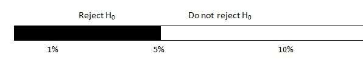

- p-value provides (informal) **strength of evidence** against $H_0$:

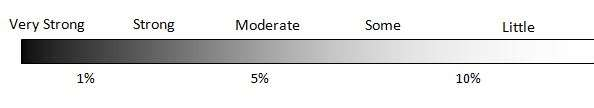

## Beware of Prosecutor’s Fallacy

**Misinterpreting p-values**

- **Correct:** If the null is true, the probability of observing a stat as, or more, extreme than the one observed is 0.01.
- **Incorrect:** Given this stat, the probability of our null being true is 0.01.

**Misinterpreting Evidence**

- **Correct:** If a defendant is innocent (assumption), the probability that their DNA will match the crime scene DNA is 1 in a million. (1 in a million people have this profile)
- **Incorrect:** Since the DNA matched (assumption), there is a 1 in a million probability that the defendant is innocent.
  - This is called the Prosecutor’s Fallacy

# Randomization Distributions

## Randomization distribution or Bootstrap?

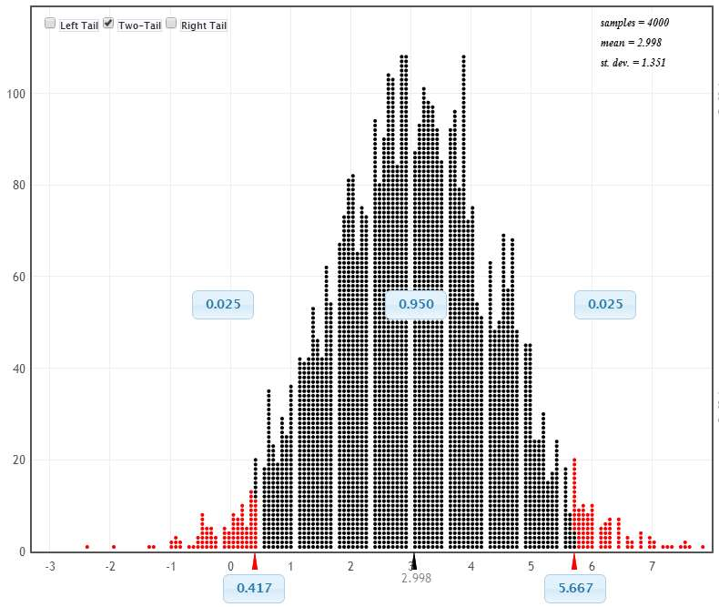

Caffeine vs Sleep

**Bootstrap distribution: NOT centered at the null hypothesis**

## Randomization distribution or Bootstrap?

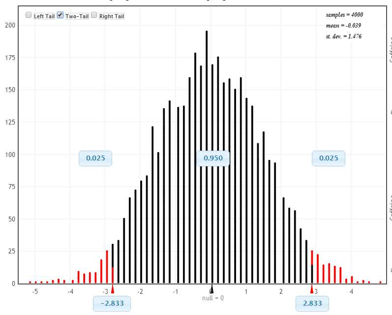

Caffeine vs Sleep

**Randomization distribution: IS centered at the null hypothesis**

# CIs and Tests

## Intervals and Tests

- Confidence Intervals and Hypothesis Tests are related!
- If a 95% CI **contains** the parameter in $H_0$, then a two-tailed test should **not reject** $H_0$ at a 5% significance level.
- If a 95% CI **misses** the parameter in $H_0$, then a two-tailed test should **reject** $H_0$ at a 5% significance level.

## Caffeine vs Sleep

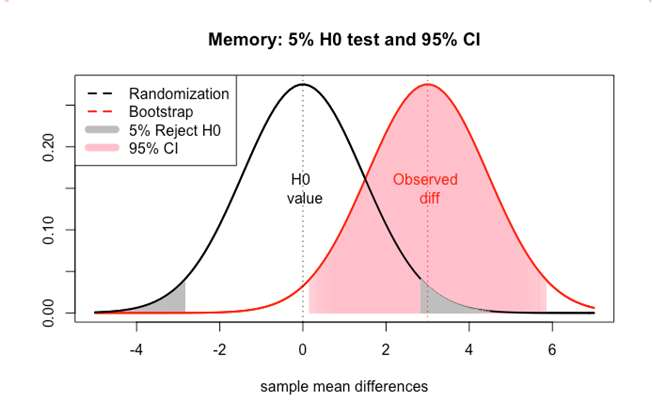

The 95% confidence interval misses null difference of 0. Reject the null at 5% level

## Caffeine vs Sleep

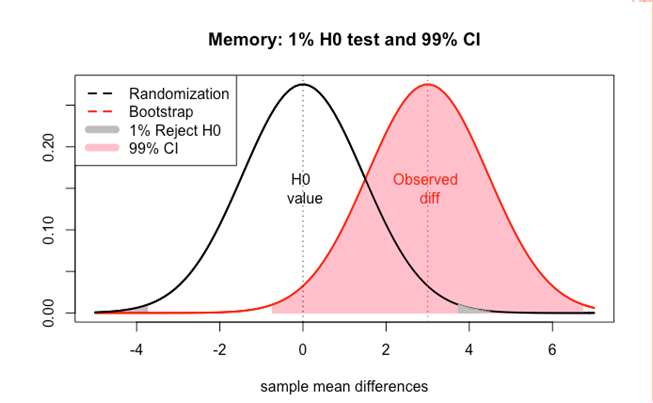

The 99% confidence interval contains null difference of 0. Do not reject the null at 1% level.

## Example of Test Scores

- Observation from data about those who get a question right on a test
- $\hat{p} = 0.567$ get it right and the 95% CI is (0.39, 0.75)

**Part a**

- Is this different from the baseline national proportion of 0.42?
- What are $H_0$ and $H_a$?
- Does the CI contain the null value?
- If the CI **does** contain the null value, then we don’t have evidence to reject the null value at the 1- (CI %) significance level. (In this case it **does**, so we **cannot** reject the null.)

## Example of Test Scores

- Observation from data about those who get a question right on a test
- $\hat{p} = 0.567$ get it right and the 95% CI is (0.39, 0.75)

**Part b**

- Can we conclude that they aren’t guessing randomly? (The question has four choices).
- What are $H_0$ and $H_a$?
- Does the CI contain the null value?
- If the CI **does** contain the null value, then we don’t have evidence to reject the null value at the 1- (CI %) significance level. (In this case it does **not**, so we reject the null.)

**Tip:** Draw the CI and find where the null value lies in/out of that CI.

# Sample Size

## Role of Sample Size

With **small sample sizes**, even large differences or effects may not be discernible.

With **large sample sizes**, even a very small difference or effect can be discernible

## ESP and Sample Size

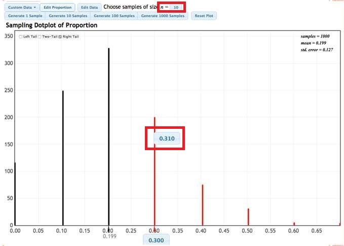

- ESP: Sample of n=10 with 30% correct guesses.
- P-value about 31%.
- No evidence for ESP

## ESP and Sample Size

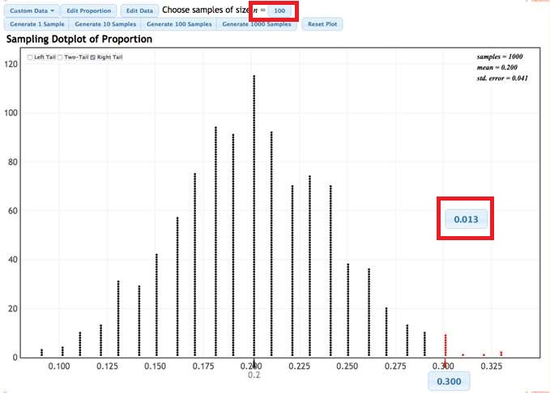

- ESP: Sample of n=100 with 30% correct guesses.
- P-value about 1.3%.
- Evidence for ESP!

## Statistical vs Practical “Significance”

- A statistically significant result is not always **practically** **significant**, especially with large sample sizes
- Ask yourself (or an expert) if the difference or effect size is meaningful.
- Motivates use of statistically discernible

# Multiple Comparisons

## Jelly Beans and p-values

[figure not shown]

http://xkcd.com/882/

## Jelly Beans and p-values

[figure not shown]

[figure not shown]

http://xkcd.com/882/

## Jelly Beans and p-values

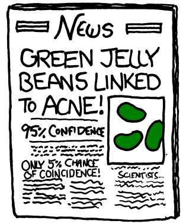

http://xkcd.com/882/

## Publication Bias

**Definition**

- **Publication bias** refers to the fact that usually only the significant results get published
- The one study that turns out significant gets published, and no one knows about all the insignificant results
- This combined with the problem of **multiple comparisons** can yield very misleading results

## Multiple Testing/Comparisons

- When multiple hypothesis tests are conducted, the chance that at least one test incorrectly rejects a true null hypothesis increases with the number of tests.
- If the null hypotheses are all true, **$\alpha$** of the tests will yield statistically discernible results just by random chance.

**Jelly Beans**

- Suppose jelly beans, regardless of color, are not associated with acne. If we use a 5% level, how many of the 20 tests do we expect to be statistically discernible?

About **20(.05) = 1** test will incorrectly reject $H_0$!

## Multiple Comparisons

- **This is a serious problem**
- The most important thing is to be aware of this issue, and not to trust claims that are obviously one of many tests (unless they specifically mention an adjustment for multiple testing)
- There are ways to account for this (e.g. Bonferroni’s Correction), but these are beyond the scope of this class

## Review Exercise

- Name the differences between the following distributions: sampling, bootstrap, randomization.
1. Why do we compute them?
2. How are they computed?
3. Where are they centered?

## Next Class

Chapter 5: Normal Distribution

Theory-based statistics!